# Ford GoBike System Data Exploration

## Preliminary Wrangling

The Ford GoBike System data set includes informations about individual rides made in a bike-sharing system covering the greater San Francisco Bay area from 2017 to 2019.

```python
# import all packages and set plots to be embedded inline
import numpy as np
import pandas as pd
import matplotlib.pyplot as plt
import seaborn as sb
import os
from math import sin, cos, sqrt, atan2, radians

%matplotlib inline
```

```python
all_files = os.listdir()
csv_files = [item for item in all_files if item[len(item)-4:len(item)]=='.csv' ]
```

```python
li=[]
for filename in csv_files:
    temp_df = pd.read_csv(filename, index_col=None)
    temp_df['year']=str(filename[0:4])
    li.append(temp_df)

df = pd.concat(li, axis=0, ignore_index=True)
```

```python
df.info()
```

```
<class 'pandas.core.frame.DataFrame'>
RangeIndex: 4890404 entries, 0 to 4890403
Data columns (total 16 columns):
 #   Column                   Dtype
---  ------                   -----
 0   duration_sec             int64
 1   start_time               object
 2   end_time                 object
 3   start_station_id         float64
 4   start_station_name       object
 5   start_station_latitude   float64
 6   start_station_longitude  float64
 7   end_station_id           float64
 8   end_station_name         object
 9   end_station_latitude     float64
 10  end_station_longitude    float64
 11  bike_id                  int64
 12  user_type                object
 13  year                     object
 14  bike_share_for_all_trip  object
 15  rental_access_method     object
dtypes: float64(6), int64(2), object(8)
memory usage: 597.0+ MB
```

```python
drop_list=['rental_access_method','bike_share_for_all_trip','start_station_latitude','start_station_longitude','end_station_latitude','end_station_longitude','bike_id']
df.drop(drop_list, axis=1, inplace=True)
```

```python
display(df.sample(5))
df.shape
```

|  | duration_sec | start_time | end_time | start_station_id | start_station_name | end_station_id | end_station_name | user_type | year |
| --- | --- | --- | --- | --- | --- | --- | --- | --- | --- |
| 2301158 | 664 | 2018-12-18 08:43:02.5930 | 2018-12-18 08:54:07.4730 | 25.0 | Howard St at 2nd St | 77.0 | 11th St at Natoma St | Subscriber | 2018 |
| 2906416 | 319 | 2019-03-14 22:25:11.5720 | 2019-03-14 22:30:31.0380 | 127.0 | Valencia St at 21st St | 139.0 | Garfield Square (25th St at Harrison St) | Customer | 2019 |
| 4628406 | 442 | 2019-11-16 15:24:00.4550 | 2019-11-16 15:31:22.5470 | 72.0 | Page St at Scott St | 120.0 | Mission Dolores Park | Customer | 2019 |
| 3128672 | 435 | 2019-04-13 10:54:51.7770 | 2019-04-13 11:02:07.6480 | 84.0 | Duboce Park | 70.0 | Central Ave at Fell St | Subscriber | 2019 |
| 1822463 | 994 | 2018-09-16 21:37:54.9240 | 2018-09-16 21:54:29.6630 | 241.0 | Ashby BART Station | 254.0 | Vine St at Shattuck Ave | Subscriber | 2018 |

```
(4890404, 9)
```

### What is the structure of your dataset?

Our data set contains informations about 4890404 trips in the Ford GoBike System. The informations we have can be categorized in 3 categories:

- Informations about the time:
  - duration_sec, start_time, end_time, year
- Informations about the location:
  - start_station_id, start_station_name, start_station_latitude, start_station_longitude, end_station_id, end_station_name, end_station_latitude, end_station_longitude
- Informations about user:
  - bike_id, user_type

### What is/are the main feature(s) of interest in your dataset?

The main feature of interest in this dataset is to have a better understanding of the workflow of the Ford GoBike System which can be achieved by analyzing the data to answer questions like:

- How long does the average trip takes?
- When are most trips taken in terms of day of the week?
- What are the most frequented stations?
- Does the duration of the trips depends on the year or user_type?

### What features in the dataset do you think will help support your investigation into your feature(s) of interest?

Almost every variable in this dataset will help us support our investigation. We are only excluding the longitude/latitude, and the bike_id variables since they do not support the analysis we're going to do.

## Univariate Exploration

### duration_sec variable

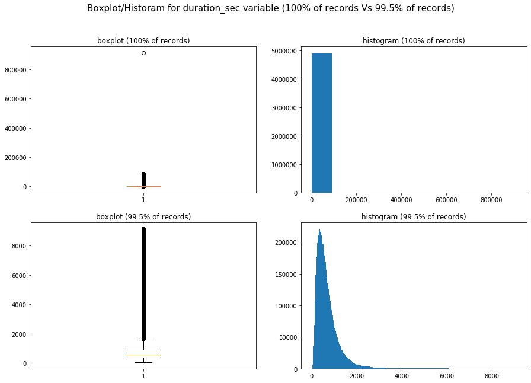

```python
fig = plt.figure(figsize=(15,10))
p995=np.percentile(df["duration_sec"],99.5)
df_temp=df.query('0 < duration_sec < @p995')
binss=np.arange(0,p995,35)

fig.suptitle('Boxplot/Historam for duration_sec variable (100% of records Vs 99.5% of records)', fontsize=15)
ax1 = plt.subplot(221)
plt.boxplot(df['duration_sec']);
ax1.set_title('boxplot (100% of records)')
ax2=plt.subplot(222)
plt.hist(df['duration_sec']);
ax2.set_title('histogram (100% of records)')
ax3=plt.subplot(223)
plt.boxplot(df_temp['duration_sec']);
ax3.set_title('boxplot (99.5% of records)')
ax4=plt.subplot(224)
plt.hist(df_temp['duration_sec'],bins=binss)
ax4.set_title('histogram (99.5% of records)');
```

```python
max_dur = df.duration_sec.max()
df.query('duration_sec==@max_dur')
```

|  | duration_sec | start_time | end_time | start_station_id | start_station_name | end_station_id | end_station_name | user_type | year |
| --- | --- | --- | --- | --- | --- | --- | --- | --- | --- |
| 4864697 | 912110 | 2019-12-19 23:15:36 | 2019-12-30 12:37:26 | NaN | NaN | NaN | NaN | Customer | 2019 |

```python
df[df['start_station_id'].isnull()].shape[0]
```

```
92505
```

```python
idx = df[df['start_station_id'].isnull()].index
df.drop(idx, inplace=True)
```

[output not shown]

```python
df['duration_sec'].mean()/60
```

```
14.256521826880197
```

As shown in the plots above, the distribution variable duration_sec which describes the duration of a trip in seconds is extremely right skewed which implies the existence of many outliers. Furher investigation of the trip corresponding to the maximum duration shows that this data lacks informations about the start and end stations. In order make sure that the data we're analysing is reliable, we will use only the data about trips that we have all the necessary informations about.

Moreover, Given that the duration_sec variable has a lot of outliers, we're going to create a new categorical variable that labels the trips with duration less than the `upper_quartile + 1.5 * IQR` as Medium, and labels the trips with duration more than the `upper_quartile + 1.5 * IQR` as Long. That way we can analyse each category individually.

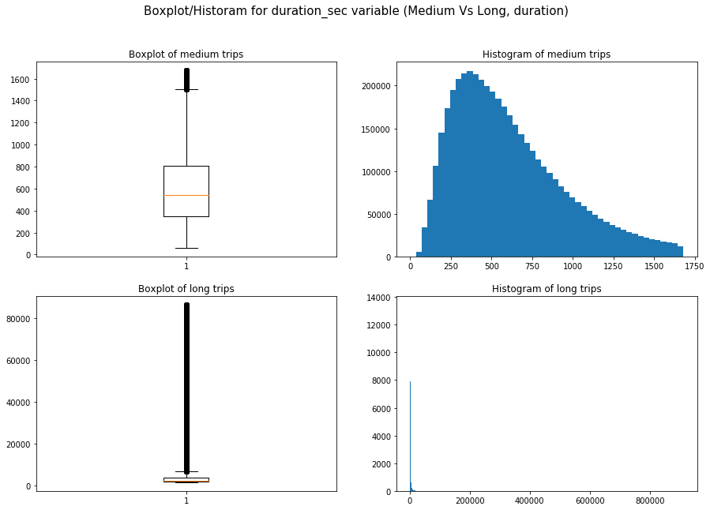

```python
fig = plt.figure(figsize=(15,10))


p25=np.percentile(df["duration_sec"],25)
p75=np.percentile(df["duration_sec"],75)
IQR=p75-p25
upper_whisker = df[df["duration_sec"]<=p75+1.5*IQR]["duration_sec"].max()

df_temp_long=df.query('@upper_whisker < duration_sec')
df_temp_medium=df.query('duration_sec <= @upper_whisker')
binss_long=np.arange(upper_whisker,max_dur+35,35)
binss_medium=np.arange(0,upper_whisker+35,35)

fig.suptitle('Boxplot/Historam for duration_sec variable (Medium Vs Long, duration)', fontsize=15)
ax1 = plt.subplot(221)
plt.boxplot(df_temp_medium['duration_sec']);
ax1.set_title('Boxplot of medium trips')
ax2=plt.subplot(222)
plt.hist(df_temp_medium['duration_sec'],bins=binss_medium);
ax2.set_title('Histogram of medium trips')
ax3=plt.subplot(223)
plt.boxplot(df_temp_long['duration_sec']);
ax3.set_title('Boxplot of long trips')
ax4=plt.subplot(224)
plt.hist(df_temp_long['duration_sec'],bins=binss_long)
ax4.set_title('Histogram of long trips');
```

The right skewness of the distribution is maintained even after the creation of two categories, however the number of outliers is severly reduced for the Medium duration category which make it possible for us to extract better information about this category on average. In the other hand, the distribution of the Long duration category inherited the extreme righ skewness characteristic. We will keep the latter category on its current state, since we are more interested in the Medium duration category wich represent more than 75% of the data in hand.

```python
df['duration_class']='Medium'
idx_m = df.query('duration_sec <= @upper_whisker').index
idx_l = df.query('@upper_whisker < duration_sec').index
df.loc[idx_m,'duration_class']='Medium'
df.loc[idx_l,'duration_class']='Long'
```

```python
df.groupby('duration_class')['duration_sec'].min()/60,df.groupby('duration_class')['duration_sec'].max()/60
```

```
(duration_class
 Long      27.9
 Medium     1.0
 Name: duration_sec, dtype: float64,
 duration_class
 Long      1439.483333
 Medium      27.883333
 Name: duration_sec, dtype: float64)
```

```python
display(df.sample(3))
sum(df.duration_class.isnull())
```

|  | duration_sec | start_time | end_time | start_station_id | start_station_name | end_station_id | end_station_name | user_type | year | duration_class |
| --- | --- | --- | --- | --- | --- | --- | --- | --- | --- | --- |
| 411036 | 372 | 2017-08-24 19:42:51.4430 | 2017-08-24 19:49:04.3230 | 42.0 | San Francisco City Hall (Polk St at Grove St) | 3.0 | Powell St BART Station (Market St at 4th St) | Subscriber | 2017 | Medium |
| 385358 | 24057 | 2017-09-02 09:36:21.4680 | 2017-09-02 16:17:19.0770 | 8.0 | The Embarcadero at Vallejo St | 53.0 | Grove St at Divisadero | Customer | 2017 | Long |
| 1115013 | 2054 | 2018-05-05 13:59:59.0940 | 2018-05-05 14:34:13.9910 | 210.0 | 45th St at Manila | 166.0 | College Ave at Alcatraz Ave | Subscriber | 2018 | Long |

```
0
```

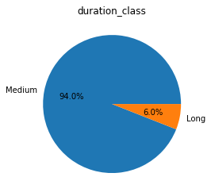

```python
dc = df['duration_class'].value_counts()
plt.pie(x=dc, labels=dc.index, autopct='%1.1f%%')
plt.title('duration_class');
```

### station_id variables

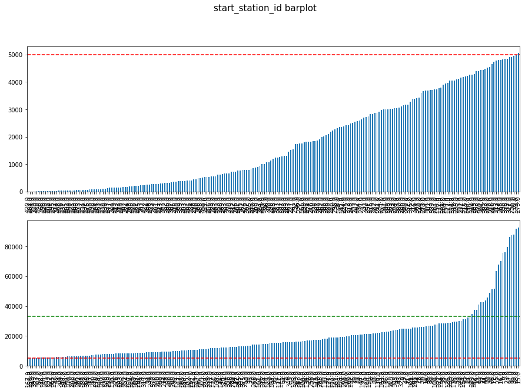

```python
start_stations = df['start_station_id'].value_counts().sort_values()
start_stations_grp1=start_stations[start_stations<start_stations.median()]
start_stations_grp2=start_stations[start_stations>=start_stations.median()]

fig=plt.figure(figsize=(15,10))
fig.suptitle('start_station_id barplot', fontsize=15)
plt.subplot(211)
start_stations_grp1.plot(kind='bar')
plt.hlines(5000,0,500, colors='red', linestyle='dashed',label='Scale Comparaison')
plt.subplot(212)
start_stations_grp2.plot(kind='bar')
plt.hlines(5000,0,500, colors='red', linestyle='dashed',label='Scale Comparaison');
plt.hlines(33000,0,500, colors='green', linestyle='dashed',label='Scale Comparaison');
```

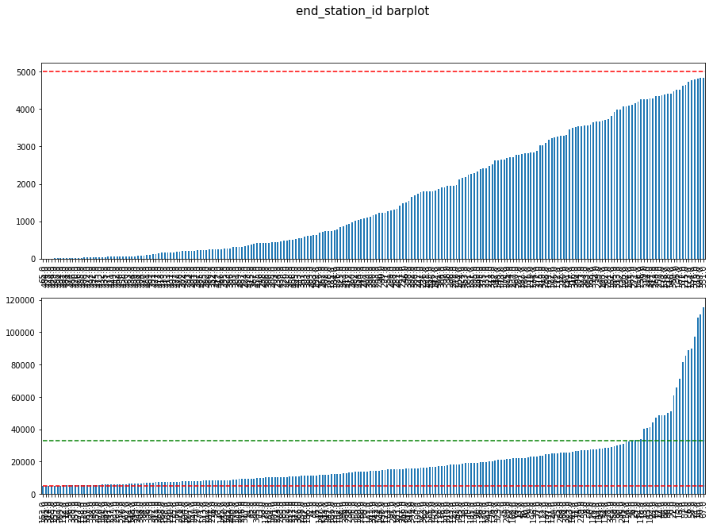

```python
end_stations = df['end_station_id'].value_counts().sort_values()
end_stations_grp1=end_stations[end_stations<end_stations.median()]
end_stations_grp2=end_stations[end_stations>=end_stations.median()]

fig2=plt.figure(figsize=(15,10))
fig2.suptitle('end_station_id barplot', fontsize=15)
plt.subplot(211)
end_stations_grp1.plot(kind='bar')
plt.hlines(5000,0,500, colors='red', linestyle='dashed',label='Scale Comparaison')
plt.subplot(212)
end_stations_grp2.plot(kind='bar')
plt.hlines(5000,0,500, colors='red', linestyle='dashed',label='Scale Comparaison');
plt.hlines(33000,0,500, colors='green', linestyle='dashed',label='Scale Comparaison');
```

As a second exploration, we targeted the variables start_station_id, and start_station_id individually. We used the bar plot to see the frequency of each staion. Since we have more than 400 stations in our dataset we created two sub-groups after ordering them by ascending frequency, the separation threshhold we used is the frequency median. Finally, we have plotted an horizontal line so that the difference in scale is clear.

We can clearly observe in the second sub-plot of in each figure that there is a change in the increase rate of the frequency starting from the frequency 33000 shown by the green line. Our investigation will focus more on the stations with frequency greater than 33000. Thus we need to create a new categorical variable named `station_freq` which indicates whether a certain trip was tanken between highly frequented stations or no.

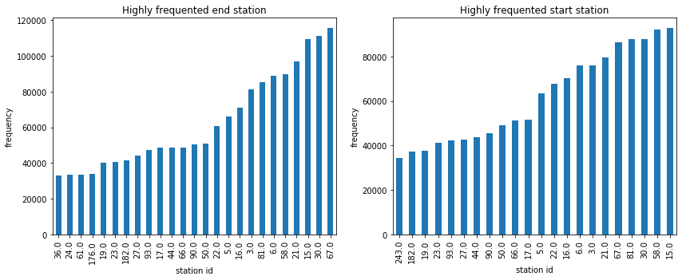

```python
hf_end_st = df['end_station_id'].value_counts()[df['end_station_id'].value_counts()>33000].sort_values()
hf_start_st = df['start_station_id'].value_counts()[df['start_station_id'].value_counts()>33000].sort_values()
plt.figure(figsize=(14,5))
plt.subplot(121)
hf_end_st.plot(kind='bar')
plt.xlabel("station id")
plt.ylabel("frequency")
plt.title('Highly frequented end station')
plt.subplot(122)
hf_start_st.plot(kind='bar')
plt.xlabel("station id")
plt.title('Highly frequented start station')
plt.ylabel("frequency");
```

```python
df['station_freq']='Noraml'
hf_end_st_id = list(df['end_station_id'].value_counts()[df['end_station_id'].value_counts()>33000].index)
hf_start_st_id = list(df['start_station_id'].value_counts()[df['start_station_id'].value_counts()>33000].index)
hf_start_end_st_id = list(set(hf_end_st_id)&set(hf_start_st_id))

idx1 = df.query('end_station_id in @hf_end_st_id').index
idx2 = df.query('end_station_id in @hf_start_st_id').index
idx3 = df.query('end_station_id in @hf_start_end_st_id').index

df.loc[idx1,'station_freq']='High_end'
df.loc[idx2,'station_freq']='High_start'
df.loc[idx3,'station_freq']='High_start_end'
```

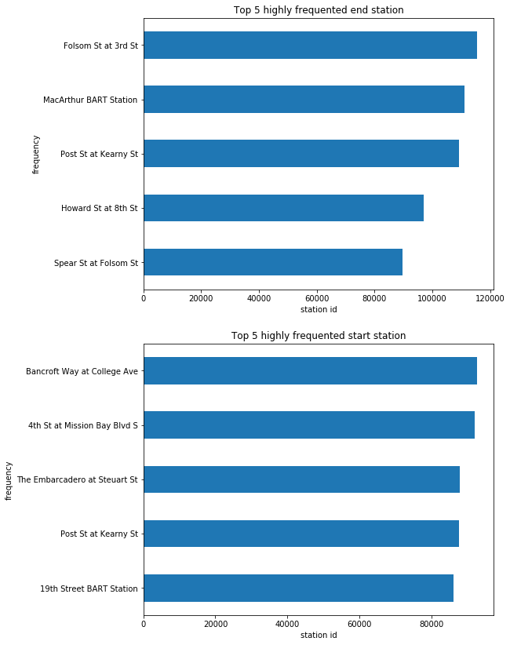

```python
top5_end = hf_end_st_id[-5:]
top5_start = hf_start_st_id[-5:]
hf_end_st_names = df.query('end_station_id in @top5_end')['end_station_name'].unique()
hf_start_st_names = df.query('start_station_id in @top5_start')['start_station_name'].unique()

hf_end_st = df['end_station_id'].value_counts().sort_values().tail(5)
hf_start_st = df['start_station_id'].value_counts().sort_values().tail(5)

plt.figure(figsize=(8,14))
plt.subplot(211)
ax = hf_end_st.plot(kind='barh')
ax.set_yticklabels(list(hf_end_st_names))
plt.xlabel("station id")
plt.ylabel("frequency")
plt.title('Top 5 highly frequented end station')
plt.subplot(212)
ax2 = hf_start_st.plot(kind='barh' )
ax2.set_yticklabels(list(hf_start_st_names))
plt.xlabel("station id")
plt.title('Top 5 highly frequented start station')
plt.ylabel("frequency");
```

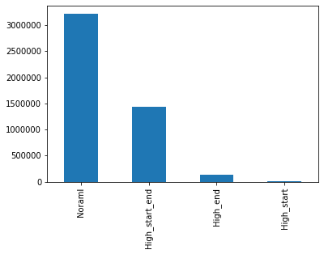

```python
f = df.station_freq.value_counts()
f.plot(kind='bar');
```

In this next section of univariate exploration, we shall plot two bar charts for both variables 'user_type' and 'year', to highlight the difference in number of trips made in each category for both variables.

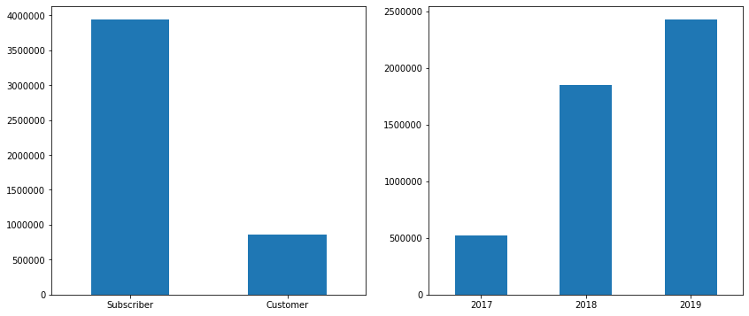

```python
users = df['user_type'].value_counts()
years = df['year'].value_counts().sort_values()
plt.figure(figsize=(14,6))
plt.subplot(1,2,1)
users.plot(kind='bar',rot=0)
plt.subplot(1,2,2)
years.plot(kind='bar',rot=0);
```

We can see clearly in the first chart that 80% of the trips are taken by members and only 20% are taken by casual users. On the second chart, we can see the increase of number of trips from 2017 to 2019.

```python
week_days={
    '0': 'Monday',
    '1': 'Tuesday',
    '2': 'Wednesday',
    '3': 'Thursday',
    '4': 'Friday',
    '5': 'Saturday',
    '6': 'Sunday'
}

df['start_time'] = pd.to_datetime(df['start_time'])
df['end_time'] = pd.to_datetime(df['end_time'])
df['trip_day'] = df.start_time.dt.dayofweek
for i in list(week_days.keys()):
    df.trip_day.replace(int(i),week_days[i],inplace=True)
```

```python
dotw = df['trip_day'].value_counts()
dotw
```

```
Tuesday      819156
Thursday     811732
Wednesday    806163
Monday       757725
Friday       755275
Saturday     448462
Sunday       399386
Name: trip_day, dtype: int64
```

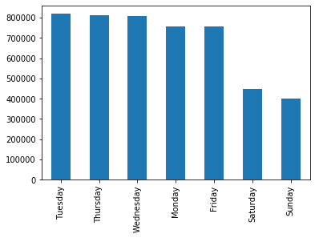

```python
dotw.plot(kind='bar');
```

In the above univariate exploration, we have extracted the day of the week of each trip and we've plotted the bar chart for the frequecy of trips on each day. A clear difference in frequency is shown between the workdays and weekends.

### Discuss the distribution(s) of your variable(s) of interest. Were there any unusual points? Did you need to perform any transformations?

The boxplot of the variable 'duration_sec' showed that there is one outlier with a value 10 times bigger than the second outlier. Further investigation of this point showed that the corresponding trip lacked informations about the start and end stations. Since we have more than 4.5 million record where 92000 trips lacks informations about stations which represent 2% of the whole dataset, we decided to drop those records and use only records with complete informations.

### Of the features you investigated, were there any unusual distributions? Did you perform any operations on the data to tidy, adjust, or change the form of the data? If so, why did you do this?

The boxplot and histogram of the first variable 'duration_sec' showed that it had many outliers that we had to clean in order to get more accurate results that can be plotted clearly. So we created a new variable to distinguish medium from long duration trips. The same kind of treatment was made to the station id variables so that we have a clear distinction of the highly frequented stations from the rest.

## Bivariate Exploration

First, we begin by exploring the relationship between the trip_day variable and the duration_sec variable.

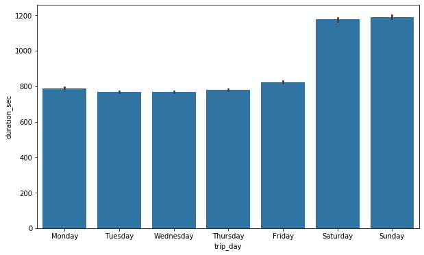

```python
l=[week_days[item] for item in week_days.keys()]
dotw=pd.api.types.CategoricalDtype(categories=l, ordered=True)
df['trip_day']=df['trip_day'].astype(dotw)
plt.figure(figsize=(10,6))
sb.barplot(data=df, x='trip_day',y='duration_sec', color=sb.color_palette()[0])
```

As we can see in the bar plot above, the average duration of a trip is around 13 minutes for all the days of work, but it is 50% longer for the weekend days.

```python
avg_dur = df.groupby('duration_class')['duration_sec'].mean()/60
display(avg_dur)
print(avg_dur[0]/avg_dur[1])
```

```
duration_class
Long      78.432987
Medium    10.178962
Name: duration_sec, dtype: float64
```

```
7.705401100643367
```

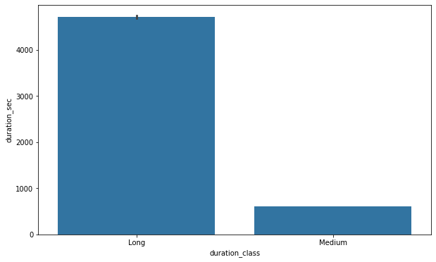

```python
plt.figure(figsize=(10,6))
sb.barplot(data=df, x='duration_class',y='duration_sec', color=sb.color_palette()[0])
```

This second bivariate exploration shows that the average duration of the trips in the long duration class is 7.7 times bigger than the average duration of trips in the medium duration class which is around 10 minutes.

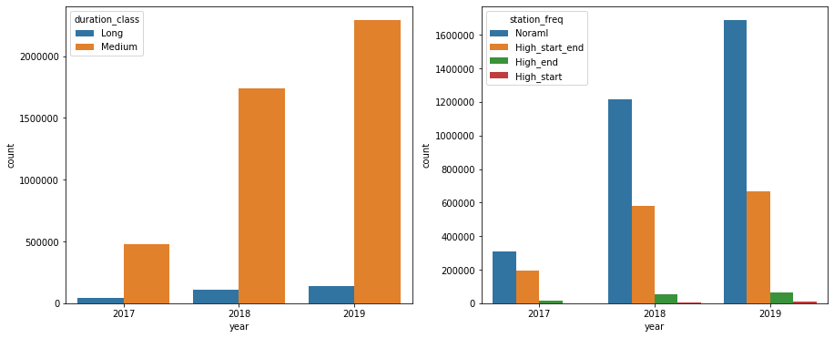

```python
plt.figure(figsize=(15,6))
plt.subplot(121)
sb.countplot(data=df, x='year', hue='duration_class')
plt.subplot(122)
sb.countplot(data=df, x='year', hue='station_freq')
```

The charts above presenting the relationship between the year and the duration classes in the first bar plot, also the year and the station frequency in the second bar plot.

In the first chart, we can see that the number of trips increases significantly each year with a high increase in medium duration trips but very low increase in the number of long duration trips.

In the second chart, the highest number of trips is made between stations with normal frequency, and the lowest number off trips is made between a high frequency start station and a normal frequency end station. This trend is kept over the three years.

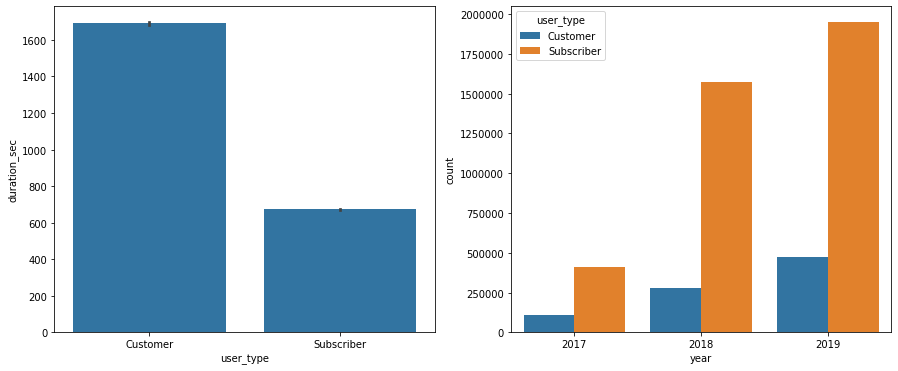

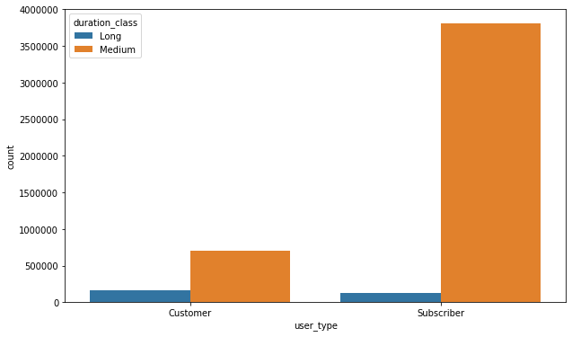

```python
plt.figure(figsize=(15,6))
plt.subplot(121)
sb.barplot(data=df, x='user_type',y='duration_sec', color=sb.color_palette()[0])
plt.subplot(122)
sb.countplot(data=df, x='year',hue='user_type')
plt.figure(figsize=(10,6))
sb.countplot(data=df, x='user_type',hue='duration_class')
```

There is also a clear increase in the number of trips made by both cusomers and subscribers over the years, with a bigger increase for the subscriber class.

### Talk about some of the relationships you observed in this part of the investigation. How did the feature(s) of interest vary with other features in the dataset?

The first bivariate exploration relating the trip_day to the duration_sec showed us that the trips taken in the weekend days are on average longer than the ones taken in the rest of the week, even though we've seen that the number of trips taken during the weekends is less than the ones taken during the rest of the week, which suggest that on the weekends people tends to go for long rides to hangout, on the other hand people on workdays tends to go for short rides that aims to get them to a certain place directly.

The bilateral relationship between the duration_class, the station_freq, and the year variable made it clear to us that the distribution of trips proportion over the different classes of both variables duration_class, and station_freq was maintained through the years with an increase in the total number of trips made each year.

As a final observation, the relationship between the user_type and duration_sec variables presented in the barplot above highlights the fact that customers take on average longer trips than members. This observation is also supported by the barplot relating the user_typ variable to the duration_class, where we can see clearly that the proportion of long trips among the cutomer class is much bigger than the proportion of long trips in the subscriber class.

### Did you observe any interesting relationships between the other features (not the main feature(s) of interest)?

All the investigated features are main features.

## Multivariate Exploration

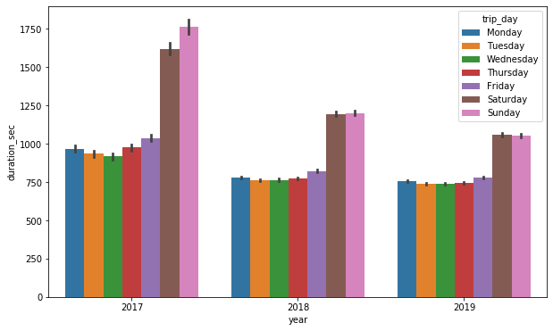

```python
plt.figure(figsize=(10,6))
sb.barplot(data=df, x='year', y='duration_sec', hue='trip_day')
```

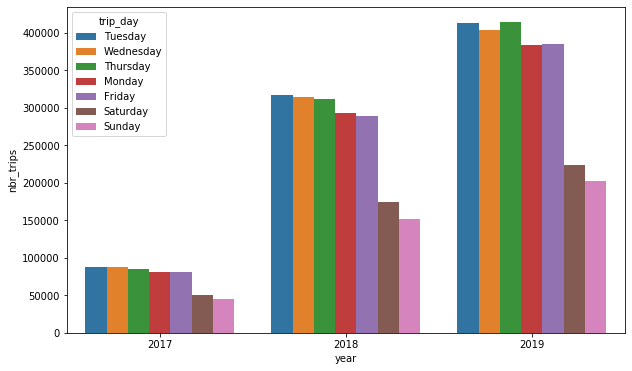

```python
dotw_trips_per_year = df.groupby('year')['trip_day'].value_counts()
df_temp = dotw_trips_per_year.to_frame()
df_temp.rename(columns={'trip_day':'nbr_trips'},inplace=True)
df_temp = df_temp.reset_index()
plt.figure(figsize=(10,6))
sb.barplot(data=df_temp, x='year', y='nbr_trips', hue='trip_day')
```

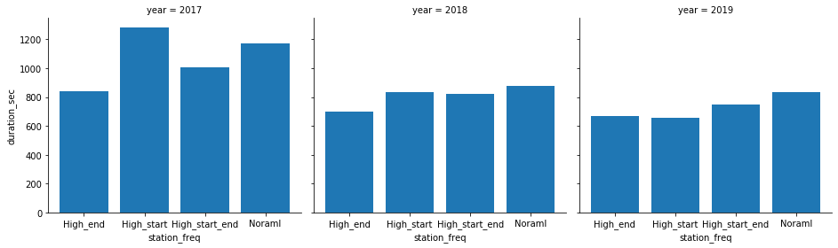

```python
df_temp=df.groupby(['year','station_freq'])['duration_sec'].mean().reset_index()
plt.figure(figsize=(15,6))
plot = sb.FacetGrid(df_temp, col='year', height=4, aspect=1.1)
plot.map(plt.bar,'station_freq','duration_sec')
```

### Talk about some of the relationships you observed in this part of the investigation. Were there features that strengthened each other in terms of looking at your feature(s) of interest?

The first multivariate exploration highlighted the fact that the observation made previouly, which states that the trips on weekend days are on average longer than those on workdays, is also maintained on each year spearatly.

Secondly, in the last two years, the average duration of the trips for each station freq class are similar. Whereas in 2017 these values are slightly different.

### Were there any interesting or surprising interactions between features?

There is no surprising interaction, the observations in this section are supporting those made in the previous sections.